# Gorrini_Assignment12IntroductiontoRMarkdown

2025-11-16

# Introduction

I am starting to learn R Markdown, and this document is my first own practice file. I am currently taking another class that provides me with R markdown files that I just have to complete the code for. So I have never created my own before.  
R Markdown lets me write normal text and also run R code in the same file.  
When I click **Knit**, RStudio runs the code chunks and creates an HTML report where the text, code, and results all appear together.  
This makes it easier for me to keep everything in one place without copying and pasting.

# Text and Math

Here is an example of inline math written with LaTeX: $\alpha + \beta = \gamma$.

Here is a displayed math formula on its own line:

$$\bar{x} = \frac{1}{n} \sum_{i = 1}^{n} x_i$$

This is the formula for the mean of values $x_1, x_2, \dots, x_n$.

# Code Chunks

R code goes inside special “chunks”.  
A code chunk starts with three backticks and `{r}`, and ends with three backticks.  
When I knit the file, RStudio runs the code inside the chunks.

# Example 1: Summary of a Dataset

In this chunk, I use the built-in `cars` dataset.  
I look at the first few rows and some summary statistics.

```r
# show the first six rows of the cars dataset
head(cars)
```

```
##   speed dist
## 1     4    2
## 2     4   10
## 3     7    4
## 4     7   22
## 5     8   16
## 6     9   10
```

```r
# show summary statistics for the variables in cars
summary(cars)
```

```
##      speed           dist
##  Min.   : 4.0   Min.   :  2.00
##  1st Qu.:12.0   1st Qu.: 26.00
##  Median :15.0   Median : 36.00
##  Mean   :15.4   Mean   : 42.98
##  3rd Qu.:19.0   3rd Qu.: 56.00
##  Max.   :25.0   Max.   :120.00
```

# Example 2: A Simple Plot with ggplot2

In this chunk, I load the `ggplot2` library and make a simple line plot using the built-in `pressure` dataset.

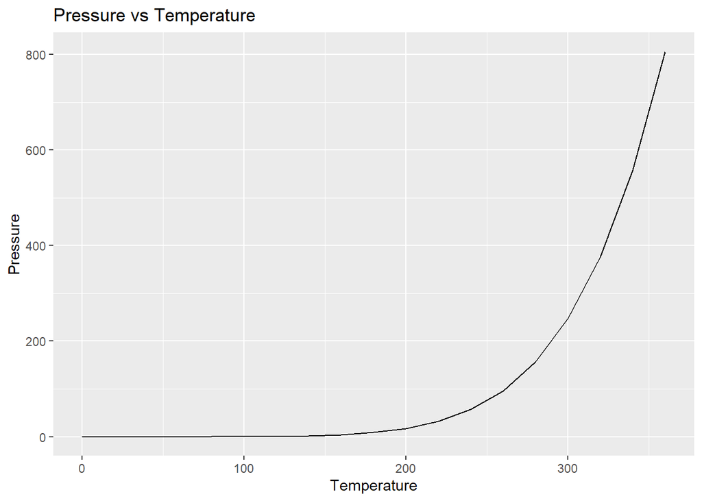

```r
# load the ggplot2 package
library(ggplot2)
# create a line plot of pressure vs. temperature
ggplot(pressure, aes(x = temperature, y = pressure)) +
  geom_line() +
  labs(
    title = "Pressure vs Temperature",
    x = "Temperature",
    y = "Pressure"
  )
```

# Reflection

After working through my other classes, the structure makes more sense to me.

I like that I can write a paragraph explaining what I am doing, and then include a code chunk that shows the actual R code and results right below it.  
If I change the code or the data, I can knit the file again and the report updates automatically.  
This is easier than writing a plain report in Word or Google Docs and copying in screenshots and tables by hand.

Overall, using R Markdown feels like a good way to create clear, reproducible reports that mix text, math, and R code.